# Targeted Marketing

[figure not shown]

Social Network Analysis

.................................................... document start ....................................................

## Business Model

**business parameters**

| initial_interest | referal_weight | budget | spend_impact_rate | spend_impact_offset |
| --- | --- | --- | --- | --- |
| 0.01 | 0.1 | 200000 | 0.000009 | -0.08 |

## Data

**nodes**

| name | product |
| --- | --- |
| Melvin Ashe | A |
| Winston Allen | A |
| Walter Alex | A |
| Sam Sutter | A |
| Andrew O'Reilly | A |
| Kevin Miller | B |
| Mary Miller | B |
| Sam Albright | B |
| Nancy Albright | B |
| Hank Hanover | B |
| Mark Shelley | C |
| Francis Aguilar | C |
| Angela Atkins | C |
| Homer Atkins | C |
| Michelle Allen | C |
| Zeb Jordan | D |
| Arthur Ah | D |
| Arthur Abbot | D |
| Sarah Atkins | D |

**links**

| person_1 | person_2 |
| --- | --- |
| Mary Miller | Hank Hanover |
| Hank Hanover | Kevin Miller |
| Hank Hanover | Nancy Albright |
| Nancy Albright | Kevin Miller |
| Nancy Albright | Sam Albright |
| Nancy Albright | Arthur Abbot |
| Nancy Albright | Sarah Atkins |
| Nancy Albright | Homer Atkins |
| Arthur Abbot | Sarah Atkins |
| Homer Atkins | Angela Atkins |
| Sarah Atkins | Homer Atkins |
| Homer Atkins | Arthur Ah |
| Arthur Ah | Sarah Atkins |
| Homer Atkins | Michelle Allen |
| Michelle Allen | Francis Aguilar |
| Arthur Ah | Zeb Jordan |
| Francis Aguilar | Mark Shelley |
| Zeb Jordan | Mark Shelley |
| Zeb Jordan | Melvin Ashe |
| Mark Shelley | Melvin Ashe |
| Mark Shelley | Andrew O'Reilly |
| Andrew O'Reilly | Melvin Ashe |
| Andrew O'Reilly | Winston Allen |
| Winston Allen | Sam Sutter |
| Winston Allen | Walter Alex |
| Sam Sutter | Walter Alex |
| Sam Albright | Mark Shelley |
| Sam Albright | Zeb Jordan |
| Nancy Albright | Melvin Ashe |
| Zeb Jordan | Hank Hanover |
| Mark Shelley | Hank Hanover |
| Melvin Ashe | Hank Hanover |

## Network Diagram

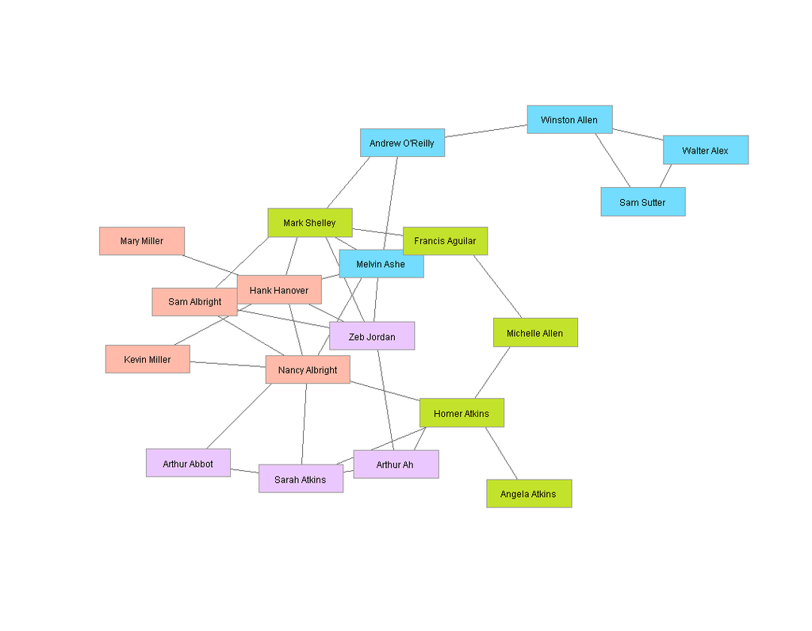

## Descriptive Statistics

### Network-Level Statistics

**network-level statistics**

| size | order | diameter | average_path_length | density | giant |
| --- | --- | --- | --- | --- | --- |
| 32 | 19 | 6 | 2.637427 | 0.1871345 | 19 |

### Node-Level Statistics

**Shortest Path Length**

|  | Melvin Ashe | Winston Allen | Walter Alex | Sam Sutter | Andrew O'Reilly | Kevin Miller | Mary Miller | Sam Albright | Nancy Albright | Hank Hanover | Mark Shelley | Francis Aguilar | Angela Atkins | Homer Atkins | Michelle Allen | Zeb Jordan | Arthur Ah | Arthur Abbot | Sarah Atkins |
| --- | --- | --- | --- | --- | --- | --- | --- | --- | --- | --- | --- | --- | --- | --- | --- | --- | --- | --- | --- |
| Melvin Ashe | 0 | 2 | 3 | 3 | 1 | 2 | 2 | 2 | 1 | 1 | 1 | 2 | 3 | 2 | 3 | 1 | 2 | 2 | 2 |
| Winston Allen | 2 | 0 | 1 | 1 | 1 | 4 | 4 | 3 | 3 | 3 | 2 | 3 | 5 | 4 | 4 | 3 | 4 | 4 | 4 |
| Walter Alex | 3 | 1 | 0 | 1 | 2 | 5 | 5 | 4 | 4 | 4 | 3 | 4 | 6 | 5 | 5 | 4 | 5 | 5 | 5 |
| Sam Sutter | 3 | 1 | 1 | 0 | 2 | 5 | 5 | 4 | 4 | 4 | 3 | 4 | 6 | 5 | 5 | 4 | 5 | 5 | 5 |
| Andrew O'Reilly | 1 | 1 | 2 | 2 | 0 | 3 | 3 | 2 | 2 | 2 | 1 | 2 | 4 | 3 | 3 | 2 | 3 | 3 | 3 |
| Kevin Miller | 2 | 4 | 5 | 5 | 3 | 0 | 2 | 2 | 1 | 1 | 2 | 3 | 3 | 2 | 3 | 2 | 3 | 2 | 2 |
| Mary Miller | 2 | 4 | 5 | 5 | 3 | 2 | 0 | 3 | 2 | 1 | 2 | 3 | 4 | 3 | 4 | 2 | 3 | 3 | 3 |
| Sam Albright | 2 | 3 | 4 | 4 | 2 | 2 | 3 | 0 | 1 | 2 | 1 | 2 | 3 | 2 | 3 | 1 | 2 | 2 | 2 |
| Nancy Albright | 1 | 3 | 4 | 4 | 2 | 1 | 2 | 1 | 0 | 1 | 2 | 3 | 2 | 1 | 2 | 2 | 2 | 1 | 1 |
| Hank Hanover | 1 | 3 | 4 | 4 | 2 | 1 | 1 | 2 | 1 | 0 | 1 | 2 | 3 | 2 | 3 | 1 | 2 | 2 | 2 |
| Mark Shelley | 1 | 2 | 3 | 3 | 1 | 2 | 2 | 1 | 2 | 1 | 0 | 1 | 4 | 3 | 2 | 1 | 2 | 3 | 3 |
| Francis Aguilar | 2 | 3 | 4 | 4 | 2 | 3 | 3 | 2 | 3 | 2 | 1 | 0 | 3 | 2 | 1 | 2 | 3 | 4 | 3 |
| Angela Atkins | 3 | 5 | 6 | 6 | 4 | 3 | 4 | 3 | 2 | 3 | 4 | 3 | 0 | 1 | 2 | 3 | 2 | 3 | 2 |
| Homer Atkins | 2 | 4 | 5 | 5 | 3 | 2 | 3 | 2 | 1 | 2 | 3 | 2 | 1 | 0 | 1 | 2 | 1 | 2 | 1 |
| Michelle Allen | 3 | 4 | 5 | 5 | 3 | 3 | 4 | 3 | 2 | 3 | 2 | 1 | 2 | 1 | 0 | 3 | 2 | 3 | 2 |
| Zeb Jordan | 1 | 3 | 4 | 4 | 2 | 2 | 2 | 1 | 2 | 1 | 1 | 2 | 3 | 2 | 3 | 0 | 1 | 3 | 2 |
| Arthur Ah | 2 | 4 | 5 | 5 | 3 | 3 | 3 | 2 | 2 | 2 | 2 | 3 | 2 | 1 | 2 | 1 | 0 | 2 | 1 |
| Arthur Abbot | 2 | 4 | 5 | 5 | 3 | 2 | 3 | 2 | 1 | 2 | 3 | 4 | 3 | 2 | 3 | 3 | 2 | 0 | 1 |
| Sarah Atkins | 2 | 4 | 5 | 5 | 3 | 2 | 3 | 2 | 1 | 2 | 3 | 3 | 2 | 1 | 2 | 2 | 1 | 1 | 0 |

**node-level statistics**

|  | indegree | outdegree | betweenness | average_path_length | closeness | eccentricity | eigencentrality |
| --- | --- | --- | --- | --- | --- | --- | --- |
| Melvin Ashe | 5 | 5 | 33.016667 | 1.944444 | 0.5142857 | 3 | 0.9602457 |
| Winston Allen | 3 | 3 | 32.000000 | 3.055556 | 0.3272727 | 5 | 0.1175367 |
| Walter Alex | 2 | 2 | 0.000000 | 3.944444 | 0.2535211 | 6 | 0.0341112 |
| Sam Sutter | 2 | 2 | 0.000000 | 3.944444 | 0.2535211 | 6 | 0.0341112 |
| Andrew O'Reilly | 3 | 3 | 45.000000 | 2.333333 | 0.4285714 | 4 | 0.4543097 |
| Kevin Miller | 2 | 2 | 0.000000 | 2.611111 | 0.3829787 | 5 | 0.4458628 |
| Mary Miller | 1 | 1 | 0.000000 | 3.000000 | 0.3333333 | 5 | 0.2249368 |
| Sam Albright | 3 | 3 | 2.350000 | 2.277778 | 0.4390244 | 4 | 0.6331179 |
| Nancy Albright | 7 | 7 | 49.500000 | 1.944444 | 0.5142857 | 4 | 0.9821697 |
| Hank Hanover | 6 | 6 | 25.850000 | 2.055556 | 0.4864865 | 4 | 1.0000000 |
| Mark Shelley | 6 | 6 | 32.683333 | 2.055556 | 0.4864865 | 4 | 0.9419394 |
| Francis Aguilar | 2 | 2 | 7.900000 | 2.611111 | 0.3829787 | 4 | 0.2493614 |
| Angela Atkins | 1 | 1 | 0.000000 | 3.277778 | 0.3050847 | 6 | 0.1105545 |
| Homer Atkins | 5 | 5 | 27.483333 | 2.333333 | 0.4285714 | 5 | 0.4914915 |
| Michelle Allen | 2 | 2 | 4.550000 | 2.833333 | 0.3529412 | 5 | 0.1666451 |
| Zeb Jordan | 5 | 5 | 11.483333 | 2.166667 | 0.4615385 | 4 | 0.8905395 |
| Arthur Ah | 3 | 3 | 4.400000 | 2.500000 | 0.4000000 | 5 | 0.4237628 |
| Arthur Abbot | 2 | 2 | 0.000000 | 2.777778 | 0.3600000 | 5 | 0.3338193 |
| Sarah Atkins | 4 | 4 | 3.783333 | 2.444444 | 0.4090909 | 5 | 0.5018887 |

## Data Visualization

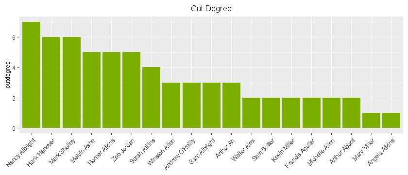

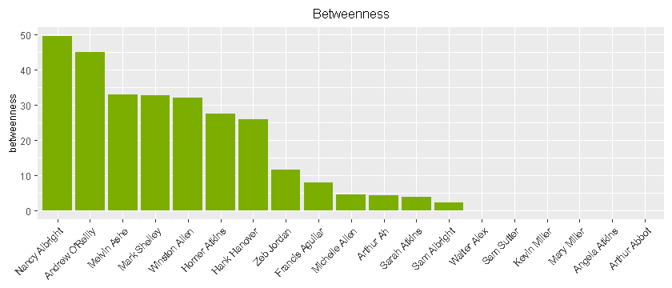

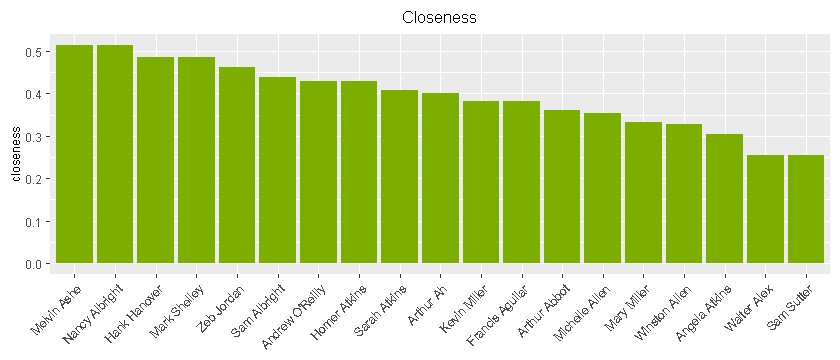

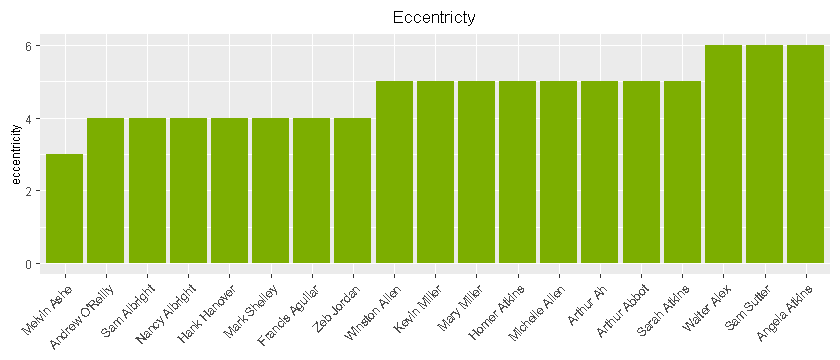

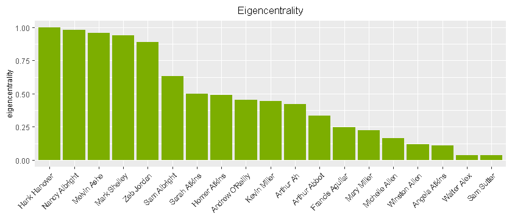

## Important Nodes

**top 4**

|  | count |
| --- | --- |
| Melvin Ashe | 5 |
| Nancy Albright | 5 |
| Mark Shelley | 4 |
| Hank Hanover | 3 |
| Andrew O'Reilly | 2 |
| Sam Albright | 1 |
| Winston Allen | 0 |
| Walter Alex | 0 |
| Sam Sutter | 0 |
| Kevin Miller | 0 |
| Mary Miller | 0 |
| Francis Aguilar | 0 |
| Angela Atkins | 0 |
| Homer Atkins | 0 |
| Michelle Allen | 0 |
| Zeb Jordan | 0 |
| Arthur Ah | 0 |
| Arthur Abbot | 0 |
| Sarah Atkins | 0 |

## Marketing Campaign Simulation

### No Marketing

**Initialize**

| referal_weight | initial_interest |
| --- | --- |
| 0.1 | 0.01 |

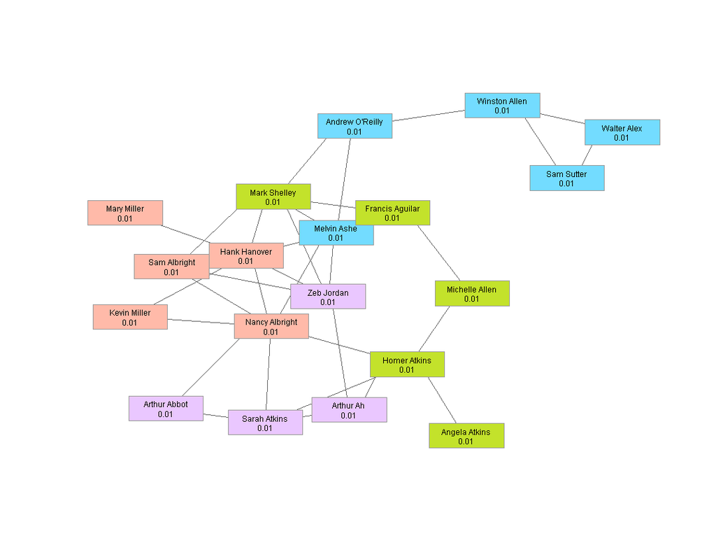

**Step 1**

Re-calculate product adoption based on interest.

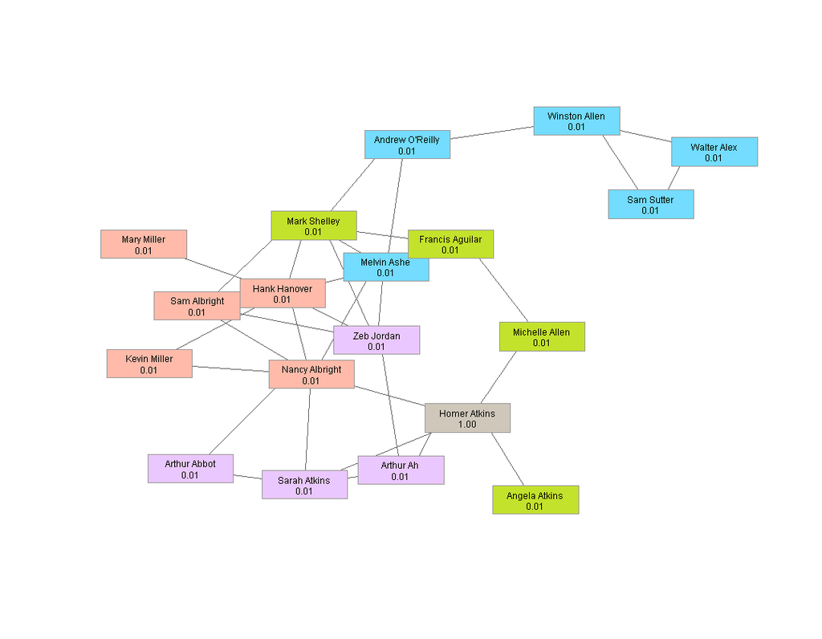

Re-calculate interest based on neighbors' interest.

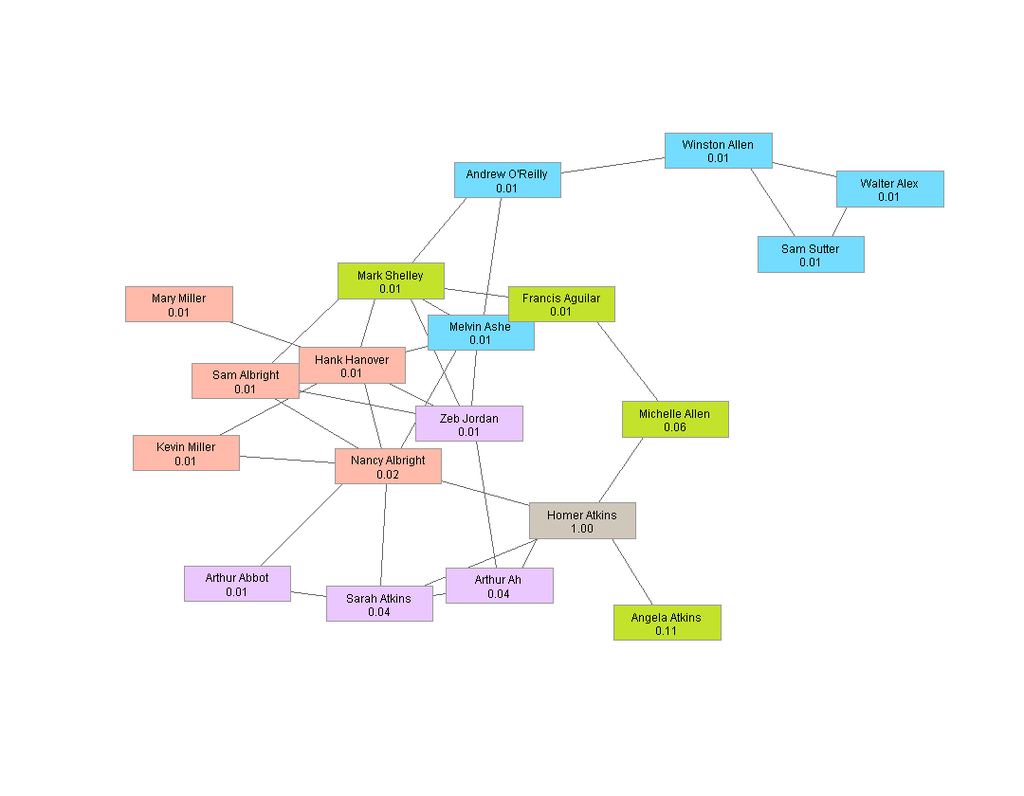

**Step 2**

Re-calculate product adoption based on interest.

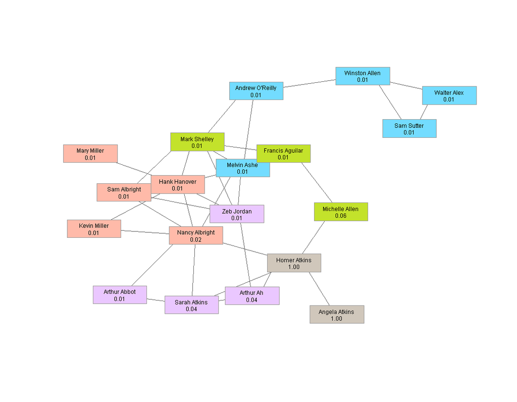

Re-calculate interest based on neighbors' interest.

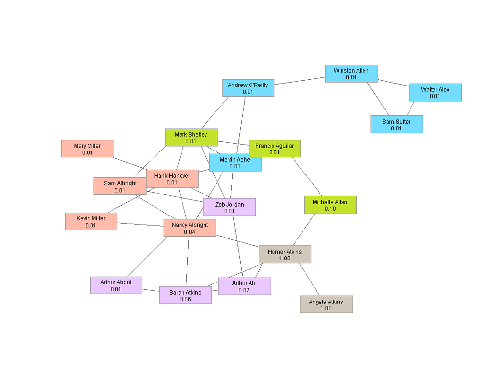

**Step 10**

Re-calculate product adoption based on interest and re-calculate interest based on neighbors' interest.

| product_adoption_rate |
| --- |
| 0.3157895 |

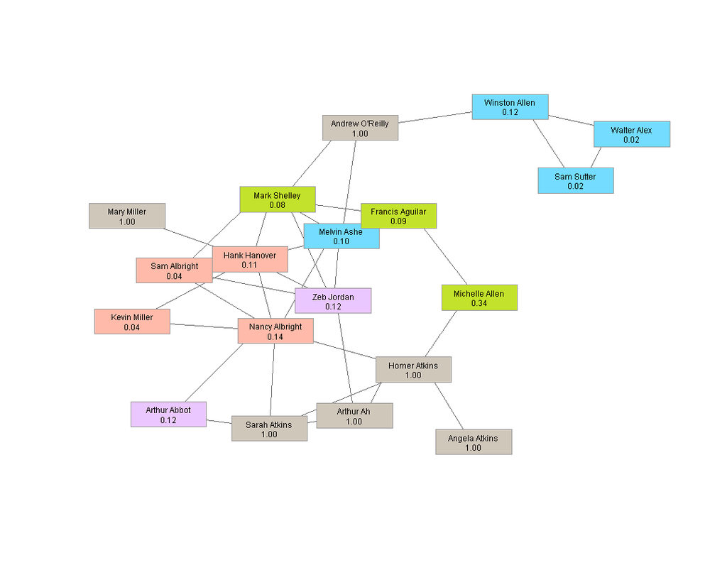

### Non-Targeted Marketing

**Initialize**

| referal_weight | nontarget_initial_interest |
| --- | --- |
| 0.1 | 0.01473684 |

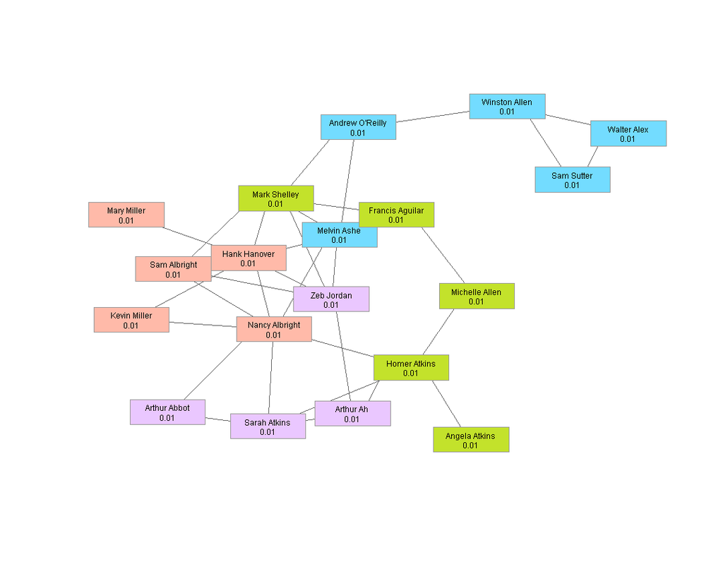

**Step 1**

Re-calculate product adoption based on interest.

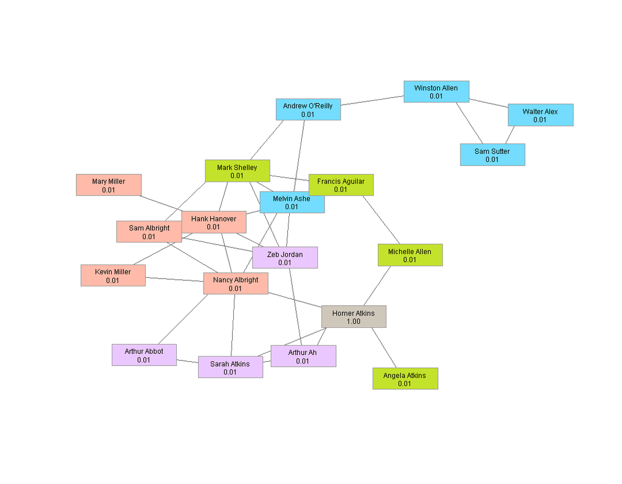

Re-calculate interest based on neighbors' interest.

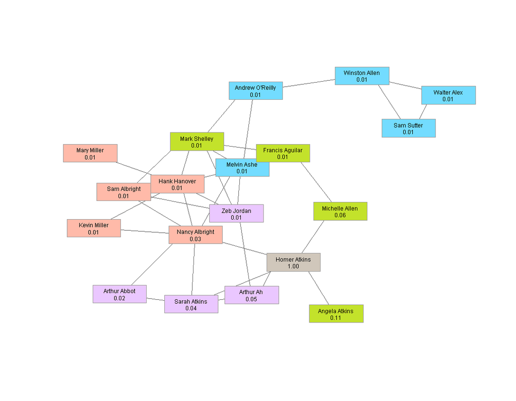

**Step 2**

Re-calculate product adoption based on interest.

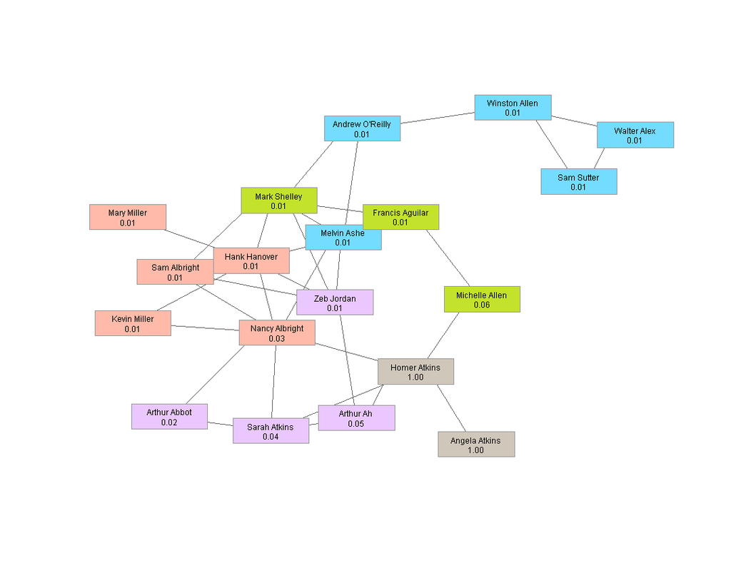

Re-calculate interest based on neighbors' interest.

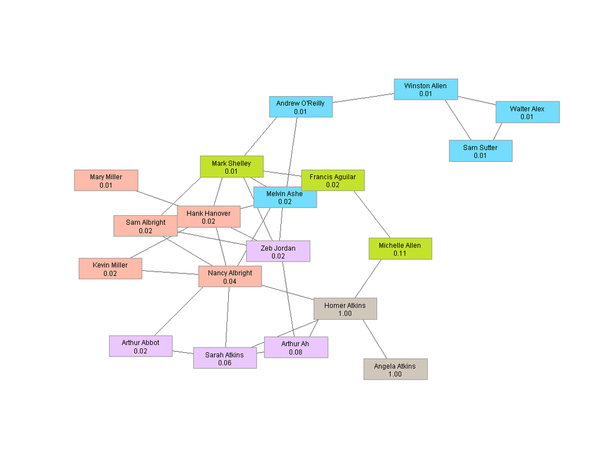

**Step 10**

Re-calculate product adoption based on interest and re-calculate interest based on neighbors' interest.

| product_adoption_rate |
| --- |
| 0.4210526 |

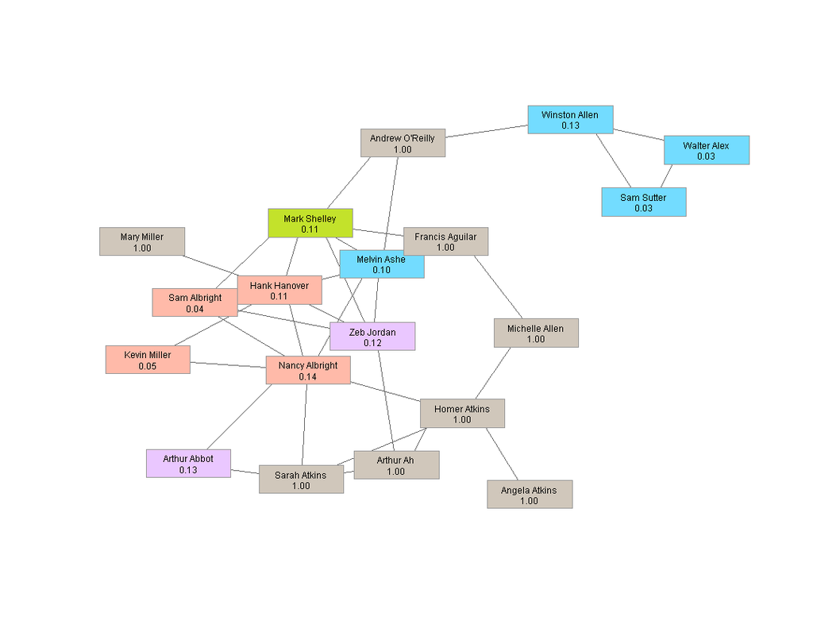

### Targeted Marketing to Unimportant Prospects

**Initialize**

| referal_weight | initial_interest | target_initial_interest |
| --- | --- | --- |
| 0.1 | 0.01 | 0.82 |

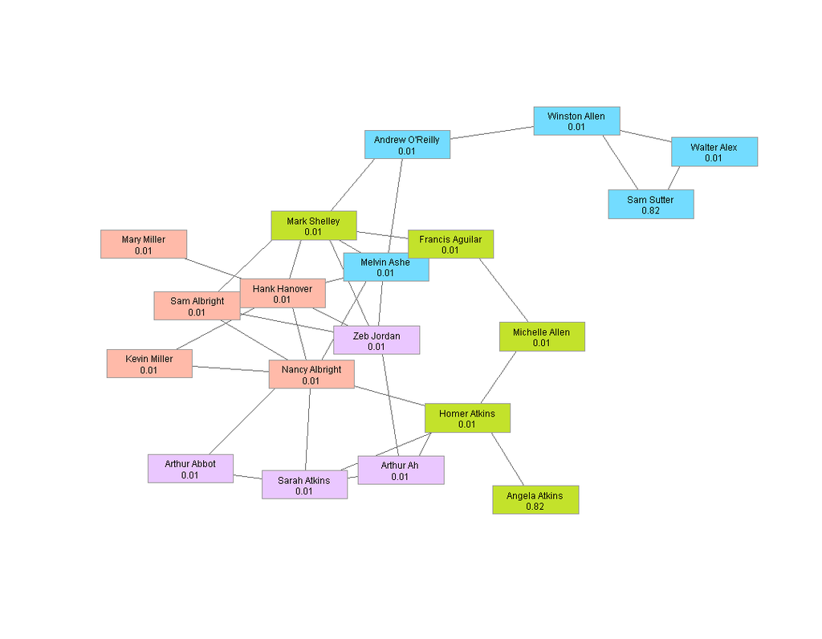

**Step 1**

Re-calculate product adoption based on interest.

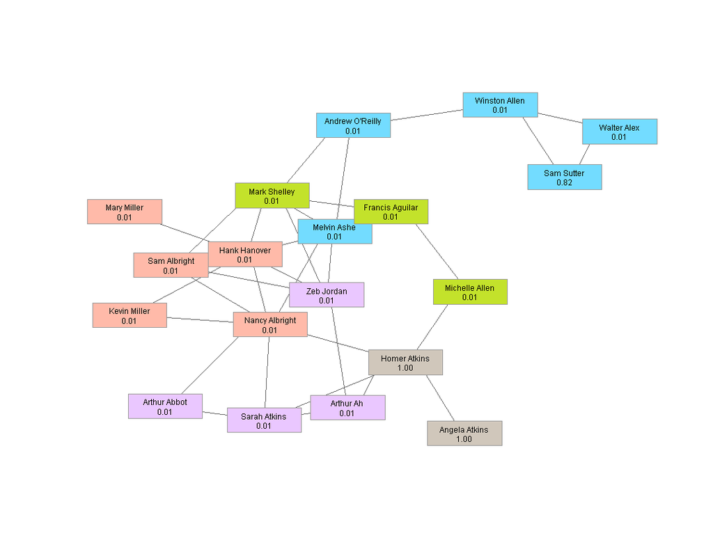

Re-calculate interest based on neighbors' interest.

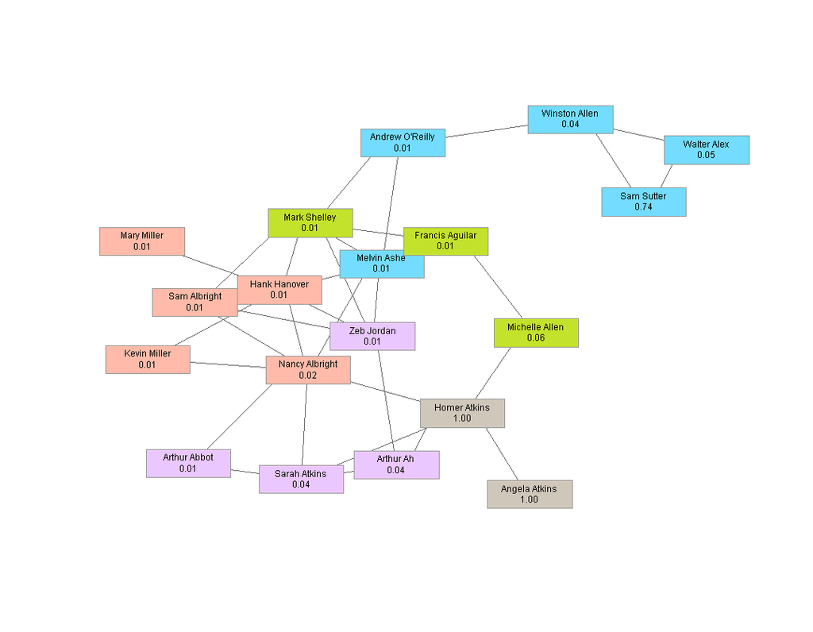

**Step 2**

Re-calculate product adoption based on interest.

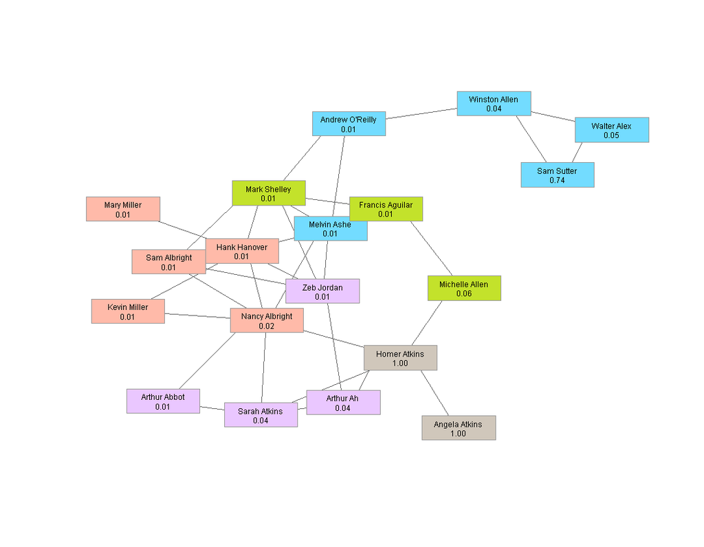

Re-calculate interest based on neighbors' interest.

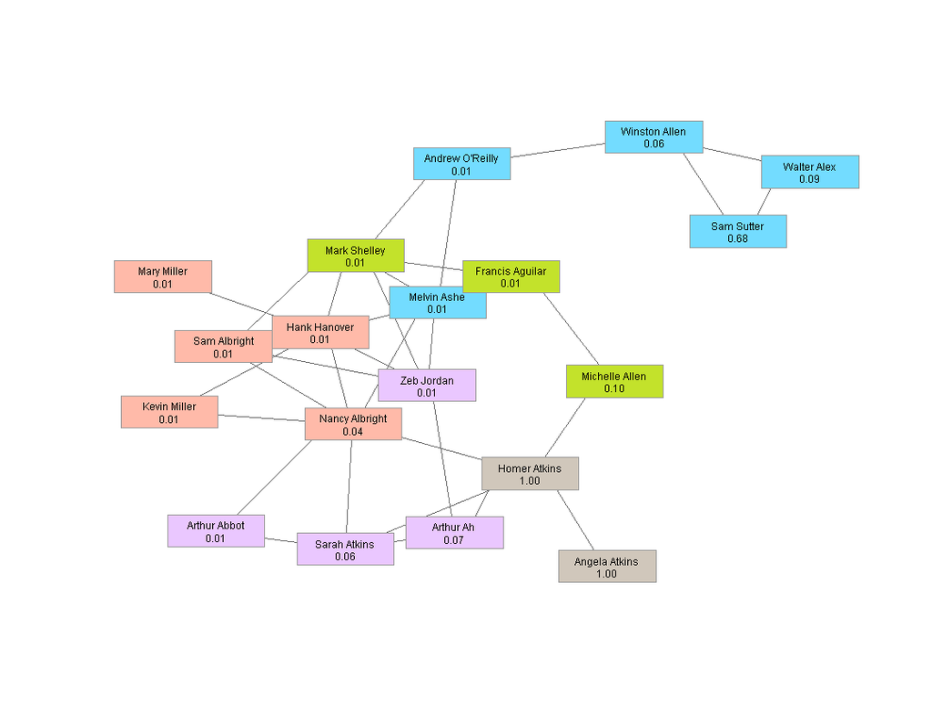

**Step 10**

Re-calculate product adoption based on interest and re-calculate interest based on neighbors' interest.

| product_adoption_rate |
| --- |
| 0.4210526 |

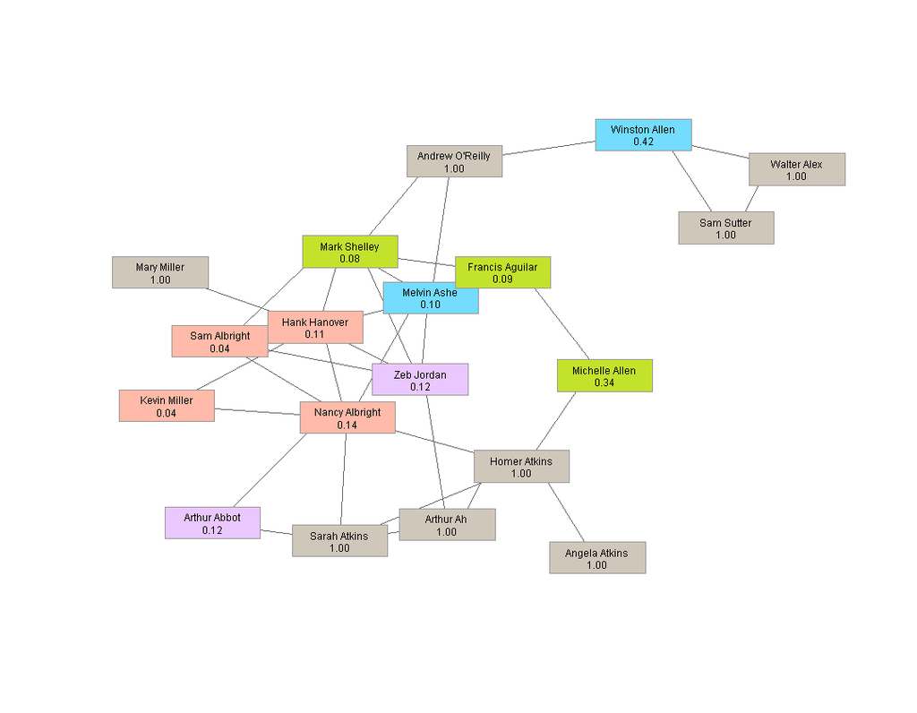

### Targeted Marketing to Important Prospects

**Initialize**

| referal_weight | initial_interest | target_initial_interest |
| --- | --- | --- |
| 0.1 | 0.01 | 0.82 |

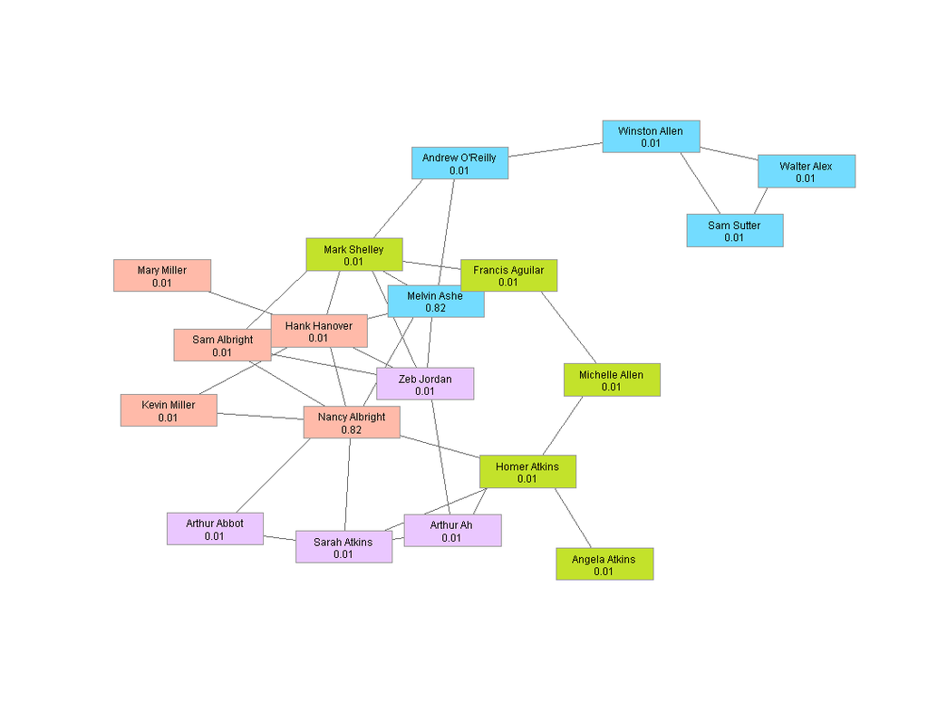

**Step 1**

Re-calculate product adoption based on interest.

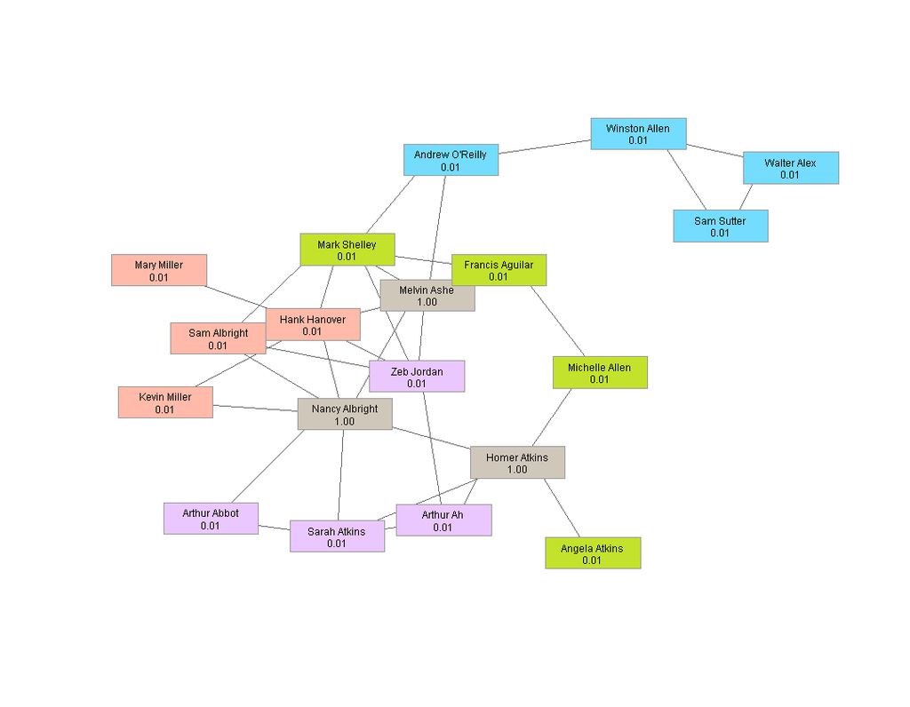

Re-calculate interest based on neighbors' interest.

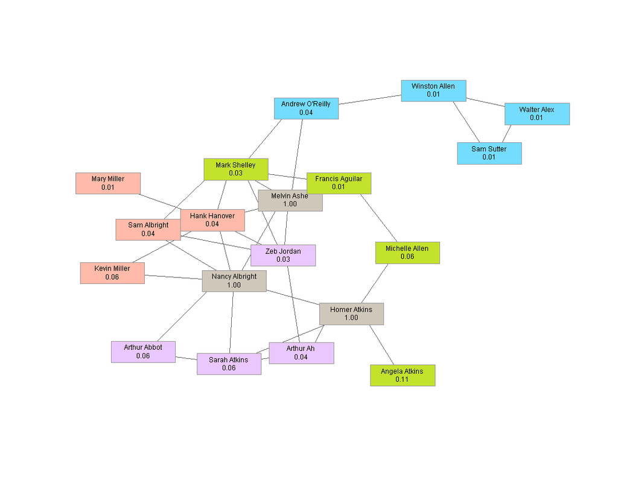

**Step 2**

Re-calculate product adoption based on interest.

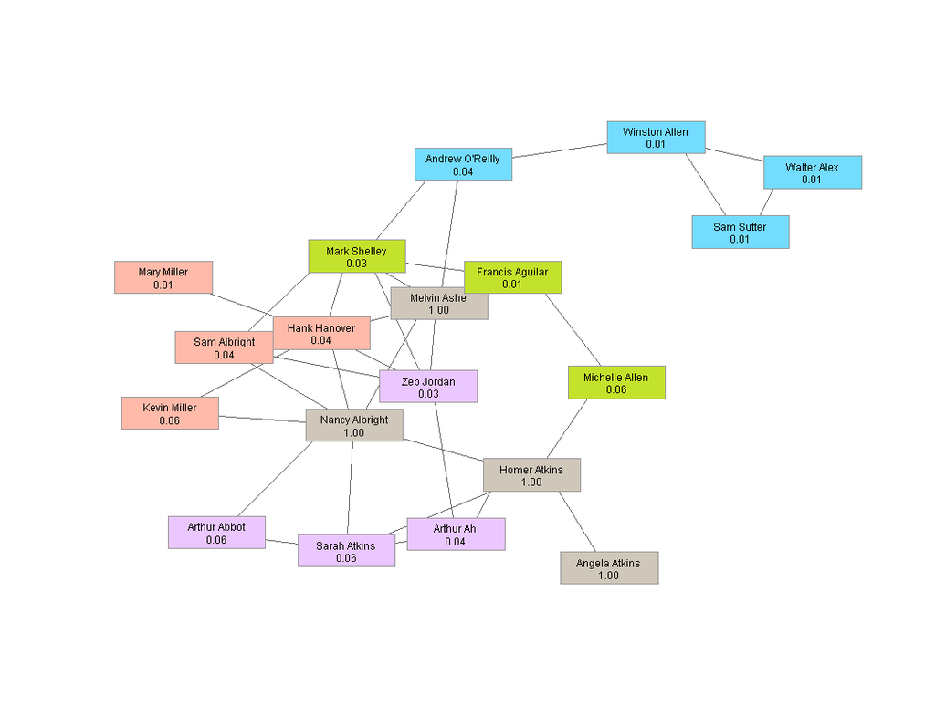

Re-calculate interest based on neighbors' interest.

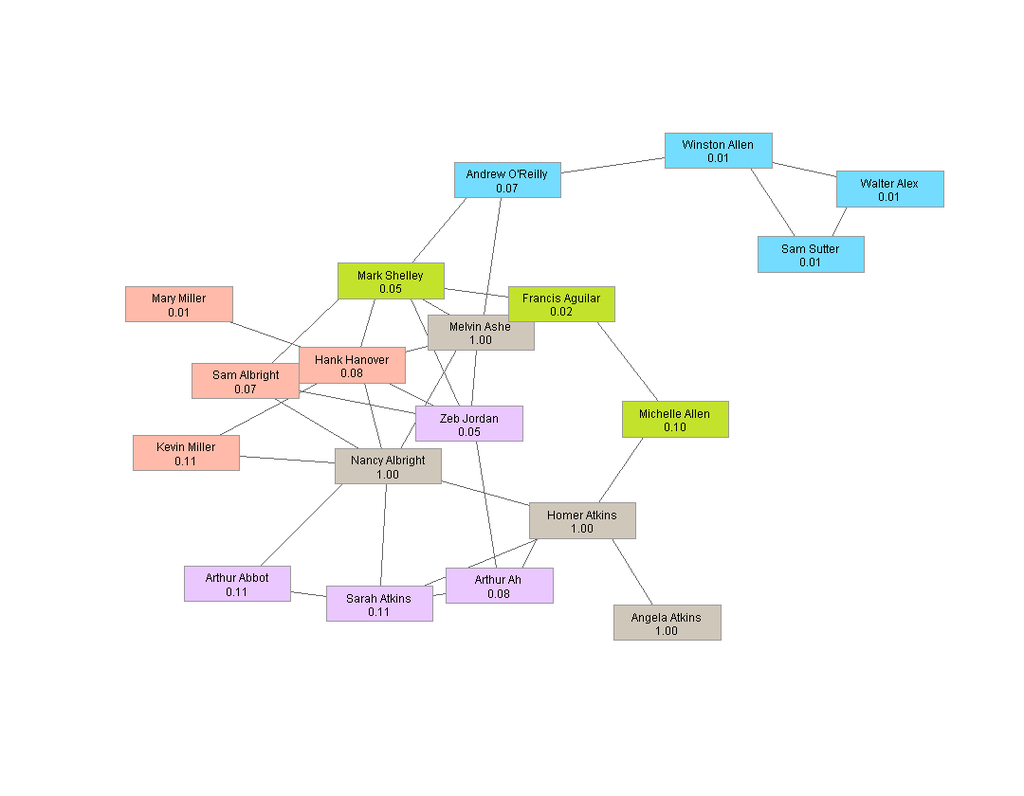

**Step 10**

Re-calculate product adoption based on interest and re-calculate interest based on neighbors' interest.

| product_adoption_rate |
| --- |
| 0.7894737 |

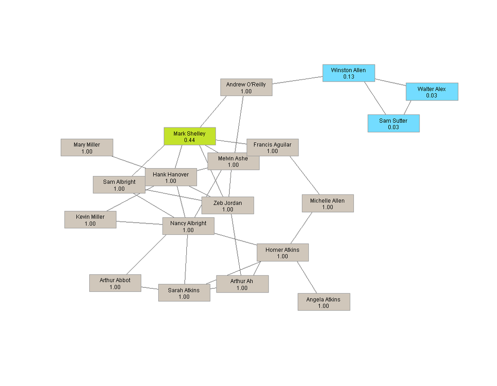

### Results

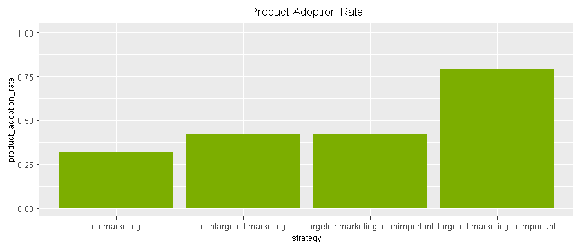

## Real Names

**top 4**

|  | real_name | count |
| --- | --- | --- |
| Melvin Ashe | Mohamed Atta | 5 |
| Nancy Albright | Nawaf Alhamzi | 5 |
| Mark Shelley | Marwan al-Shehhi | 4 |
| Hank Hanover | Hani Hanjour | 3 |
| Andrew O'Reilly | Abdulaziz Alomari | 2 |
| Sam Albright | Salem Alhamzi | 1 |
| Winston Allen | Waleed Alshehri | 0 |
| Walter Alex | Wail Alshari | 0 |
| Sam Sutter | Sata al-Suqami | 0 |
| Kevin Miller | Khalid al-Midhar | 0 |
| Mary Miller | Majed Moqed | 0 |
| Francis Aguilar | Fayez Ahmed | 0 |
| Angela Atkins | Ahmed Alghamdi | 0 |
| Homer Atkins | Hamza Alghamdi | 0 |
| Michelle Allen | Mohald Alshehri | 0 |
| Zeb Jordan | Ziad Jarrah | 0 |
| Arthur Ah | Ahmed Alhaznawi | 0 |
| Arthur Abbot | Ahmed Alnami | 0 |
| Sarah Atkins | Saeed Alghamdi | 0 |

Copyright (c) Berkeley Data Analytics Group, LLC Document revised November 22, 2019